# Survey Response Distribution

BR

28/11/2019

```r
library(skimr)
library(summarytools)
#summary table for categorical results
var_factor<-header_key %>%
  filter(type == "factor") %>%
  select(-question)

result_fac<-survey %>%
  gather(column_header, response, -survey_id) %>%
  right_join(var_factor) %>%
  select(-type) %>%
  spread(column_header, response)
```

```r
dfSummary(result_fac, style = "grid", plain.ascii = TRUE, graph.col =FALSE)
```

```
## Data Frame Summary
## result_fac
## Dimensions: 212 x 102
## Duplicates: 0
##
## +-----+--------------------------------+----------------------------+--------------------+----------+----------+
## | No  | Variable                       | Stats / Values             | Freqs (% of Valid) | Valid    | Missing  |
## +=====+================================+============================+====================+==========+==========+
## | 1   | access_target_species          | 1. community               |   8 ( 4.3%)        | 184      | 28       |
## |     | [character]                    | 2. neighboring_community   |   2 ( 1.1%)        | (86.79%) | (13.21%) |
## |     |                                | 3. no_restrictions         |  39 (21.2%)        |          |          |
## |     |                                | 4. other                   |  17 ( 9.2%)        |          |          |
## |     |                                | 5. permit_holders          | 118 (64.1%)        |          |          |
## +-----+--------------------------------+----------------------------+--------------------+----------+----------+
## | 2   | boat_material                  | 1. fg                      | 101 (47.9%)        | 211      | 1        |
## |     | [character]                    | 2. w                       | 110 (52.1%)        | (99.53%) | (0.47%)  |
## +-----+--------------------------------+----------------------------+--------------------+----------+----------+
## | 3   | boat_motorized                 | 1. n                       |   3 ( 1.4%)        | 211      | 1        |
## |     | [character]                    | 2. y                       | 208 (98.6%)        | (99.53%) | (0.47%)  |
## +-----+--------------------------------+----------------------------+--------------------+----------+----------+
## | 4   | boat_power                     | 1. n                       |  56 (26.5%)        | 211      | 1        |
## |     | [character]                    | 2. y                       | 155 (73.5%)        | (99.53%) | (0.47%)  |
## +-----+--------------------------------+----------------------------+--------------------+----------+----------+
## | 5   | boat_status                    | 1. own                     | 134 (63.5%)        | 211      | 1        |
## |     | [character]                    | 2. rent                    |   3 ( 1.4%)        | (99.53%) | (0.47%)  |
## |     |                                | 3. share_collective        |  15 ( 7.1%)        |          |          |
## |     |                                | 4. share_employee          |  59 (28.0%)        |          |          |
## +-----+--------------------------------+----------------------------+--------------------+----------+----------+
## | 6   | catch_trends                   | 1. decline_high            | 37 (17.6%)         | 210      | 2        |
## |     | [character]                    | 2. decline_low             | 62 (29.5%)         | (99.06%) | (0.94%)  |
## |     |                                | 3. improve_high            |  6 ( 2.9%)         |          |          |
## |     |                                | 4. improve_low             | 30 (14.3%)         |          |          |
## |     |                                | 5. no_change               | 75 (35.7%)         |          |          |
## +-----+--------------------------------+----------------------------+--------------------+----------+----------+
## | 7   | choice                         | 1. 1                       | 101 (47.9%)        | 211      | 1        |
## |     | [character]                    | 2. 2                       | 110 (52.1%)        | (99.53%) | (0.47%)  |
## +-----+--------------------------------+----------------------------+--------------------+----------+----------+
## | 8   | community                      | 1. ALT                     | 37 (17.5%)         | 211      | 1        |
## |     | [character]                    | 2. JPR                     |  6 ( 2.8%)         | (99.53%) | (0.47%)  |
## |     |                                | 3. MAK                     | 59 (28.0%)         |          |          |
```

[output cut: 391 more lines]

```
## | 98  | wtp_4                          | 1. n                       | 18 (39.1%)         | 46       | 166      |
## |     | [character]                    | 2. y                       | 28 (60.9%)         | (21.7%)  | (78.3%)  |
## +-----+--------------------------------+----------------------------+--------------------+----------+----------+
## | 99  | wtr_1                          | 1. n                       | 28 (66.7%)         | 42       | 170      |
## |     | [character]                    | 2. y                       | 14 (33.3%)         | (19.81%) | (80.19%) |
## +-----+--------------------------------+----------------------------+--------------------+----------+----------+
## | 100 | wtr_2                          | 1. n                       | 25 (89.3%)         | 28       | 184      |
## |     | [character]                    | 2. y                       |  3 (10.7%)         | (13.21%) | (86.79%) |
## +-----+--------------------------------+----------------------------+--------------------+----------+----------+
## | 101 | wtr_3                          | 1. n                       | 23 (92.0%)         | 25       | 187      |
## |     | [character]                    | 2. y                       |  2 ( 8.0%)         | (11.79%) | (88.21%) |
## +-----+--------------------------------+----------------------------+--------------------+----------+----------+
## | 102 | wtr_4                          | 1. n                       | 23 (100.0%)        | 23       | 189      |
## |     | [character]                    |                            |                    | (10.85%) | (89.15%) |
## +-----+--------------------------------+----------------------------+--------------------+----------+----------+
```

```r
#summary table for continuous/numeric results

var_integer<-header_key %>%
  filter(type == "integer") %>%
  select(-question)

result_int<-survey %>%
  gather(column_header, response, -survey_id) %>%
  right_join(var_integer) %>%
  select(-type) %>%
  mutate(response=as.integer(response)) %>%
  spread(column_header, response)
```

```r
dfSummary(result_int, style = "grid", plain.ascii = TRUE, graph.col =FALSE)
```

```
## Data Frame Summary
## result_int
## Dimensions: 211 x 13
## Duplicates: 0
##
## +----+-----------------------+------------------------------------+---------------------+----------+----------+
## | No | Variable              | Stats / Values                     | Freqs (% of Valid)  | Valid    | Missing  |
## +====+=======================+====================================+=====================+==========+==========+
## | 1  | survey_id             | Mean (sd) : 4366.4 (1749.4)        | 211 distinct values | 211      | 0        |
## |    | [numeric]             | min < med < max:                   |                     | (100%)   | (0%)     |
## |    |                       | 1001 < 5002 < 8006                 |                     |          |          |
## |    |                       | IQR (CV) : 2977 (0.4)              |                     |          |          |
## +----+-----------------------+------------------------------------+---------------------+----------+----------+
## | 2  | age                   | Mean (sd) : 41.9 (11.7)            | 49 distinct values  | 211      | 0        |
## |    | [integer]             | min < med < max:                   |                     | (100%)   | (0%)     |
## |    |                       | 17 < 41 < 75                       |                     |          |          |
## |    |                       | IQR (CV) : 15 (0.3)                |                     |          |          |
## +----+-----------------------+------------------------------------+---------------------+----------+----------+
## | 3  | boat_length_m         | Mean (sd) : 9.3 (7.3)              | 19 distinct values  | 211      | 0        |
## |    | [integer]             | min < med < max:                   |                     | (100%)   | (0%)     |
## |    |                       | 2 < 8 < 100                        |                     |          |          |
## |    |                       | IQR (CV) : 2.5 (0.8)               |                     |          |          |
## +----+-----------------------+------------------------------------+---------------------+----------+----------+
## | 4  | fishing_org_members   | Mean (sd) : 48.9 (71.6)            | 40 distinct values  | 123      | 88       |
## |    | [integer]             | min < med < max:                   |                     | (58.29%) | (41.71%) |
## |    |                       | 3 < 20 < 400                       |                     |          |          |
## |    |                       | IQR (CV) : 61 (1.5)                |                     |          |          |
## +----+-----------------------+------------------------------------+---------------------+----------+----------+
## | 5  | fraction_export       | Mean (sd) : 11.5 (30.4)            | 0   : 96 (86.5%)    | 111      | 100      |
## |    | [integer]             | min < med < max:                   | 5   :  1 ( 0.9%)    | (52.61%) | (47.39%) |
## |    |                       | 0 < 0 < 100                        | 65  :  1 ( 0.9%)    |          |          |
## |    |                       | IQR (CV) : 0 (2.7)                 | 80  :  2 ( 1.8%)    |          |          |
## |    |                       |                                    | 90  :  5 ( 4.5%)    |          |          |
## |    |                       |                                    | 95  :  1 ( 0.9%)    |          |          |
## |    |                       |                                    | 100 :  5 ( 4.5%)    |          |          |
## +----+-----------------------+------------------------------------+---------------------+----------+----------+
## | 6  | fraction_local_trade  | Mean (sd) : 67.5 (42.1)            | 16 distinct values  | 140      | 71       |
## |    | [integer]             | min < med < max:                   |                     | (66.35%) | (33.65%) |
## |    |                       | 0 < 95 < 100                       |                     |          |          |
## |    |                       | IQR (CV) : 82.5 (0.6)              |                     |          |          |
```

[output cut: 29 more lines]

```
## | 11 | income_expenses       | Mean (sd) : 28.6 (17.5)            | 15 distinct values  | 203      | 8        |
## |    | [integer]             | min < med < max:                   |                     | (96.21%) | (3.79%)  |
## |    |                       | 0 < 25 < 80                        |                     |          |          |
## |    |                       | IQR (CV) : 25 (0.6)                |                     |          |          |
## +----+-----------------------+------------------------------------+---------------------+----------+----------+
## | 12 | income_fishing        | Mean (sd) : 83.1 (30.4)            | 15 distinct values  | 205      | 6        |
## |    | [integer]             | min < med < max:                   |                     | (97.16%) | (2.84%)  |
## |    |                       | 0 < 100 < 100                      |                     |          |          |
## |    |                       | IQR (CV) : 25 (0.4)                |                     |          |          |
## +----+-----------------------+------------------------------------+---------------------+----------+----------+
## | 13 | years_fishing         | Mean (sd) : 23.7 (13.2)            | 51 distinct values  | 211      | 0        |
## |    | [integer]             | min < med < max:                   |                     | (100%)   | (0%)     |
## |    |                       | 1 < 22 < 98                        |                     |          |          |
## |    |                       | IQR (CV) : 16 (0.6)                |                     |          |          |
## +----+-----------------------+------------------------------------+---------------------+----------+----------+
```

```r
#cleaning market fraction section, filling NA values for rows that amount to 100% as 0.

market<-survey %>%
  select(starts_with("fraction")) %>%
  mutate(total = rowSums(., na.rm = TRUE)) %>%
  mutate_at(1:5, funs(ifelse(total == 100, replace(., is.na(.), 0), .))) %>%
  select(-total)
```

```r
dfSummary(market, style = "grid", plain.ascii = TRUE, graph.col =FALSE)
```

```
## Data Frame Summary
## market
## Dimensions: 211 x 5
## Duplicates: 163
##
## +----+-----------------------+--------------------------+--------------------+----------+---------+
## | No | Variable              | Stats / Values           | Freqs (% of Valid) | Valid    | Missing |
## +====+=======================+==========================+====================+==========+=========+
## | 1  | fraction_personal     | Mean (sd) : 5.3 (12.9)   | 11 distinct values | 207      | 4       |
## |    | [numeric]             | min < med < max:         |                    | (98.1%)  | (1.9%)  |
## |    |                       | 0 < 0 < 100              |                    |          |         |
## |    |                       | IQR (CV) : 5 (2.5)       |                    |          |         |
## +----+-----------------------+--------------------------+--------------------+----------+---------+
## | 2  | fraction_neighbor     | Mean (sd) : 2.3 (9.6)    | 0  : 181 (88.3%)   | 205      | 6       |
## |    | [numeric]             | min < med < max:         | 5  :   6 ( 2.9%)   | (97.16%) | (2.84%) |
## |    |                       | 0 < 0 < 85               | 10 :   8 ( 3.9%)   |          |         |
## |    |                       | IQR (CV) : 0 (4.1)       | 20 :   5 ( 2.4%)   |          |         |
## |    |                       |                          | 25 :   1 ( 0.5%)   |          |         |
## |    |                       |                          | 40 :   1 ( 0.5%)   |          |         |
## |    |                       |                          | 50 :   1 ( 0.5%)   |          |         |
## |    |                       |                          | 70 :   1 ( 0.5%)   |          |         |
## |    |                       |                          | 85 :   1 ( 0.5%)   |          |         |
## +----+-----------------------+--------------------------+--------------------+----------+---------+
## | 3  | fraction_local_trade  | Mean (sd) : 45.6 (46.9)  | 16 distinct values | 207      | 4       |
## |    | [numeric]             | min < med < max:         |                    | (98.1%)  | (1.9%)  |
## |    |                       | 0 < 20 < 100             |                    |          |         |
## |    |                       | IQR (CV) : 100 (1)       |                    |          |         |
## +----+-----------------------+--------------------------+--------------------+----------+---------+
## | 4  | fraction_export       | Mean (sd) : 6.2 (23)     | 0   : 192 (92.8%)  | 207      | 4       |
## |    | [numeric]             | min < med < max:         | 5   :   1 ( 0.5%)  | (98.1%)  | (1.9%)  |
## |    |                       | 0 < 0 < 100              | 65  :   1 ( 0.5%)  |          |         |
## |    |                       | IQR (CV) : 0 (3.7)       | 80  :   2 ( 1.0%)  |          |         |
## |    |                       |                          | 90  :   5 ( 2.4%)  |          |         |
## |    |                       |                          | 95  :   1 ( 0.5%)  |          |         |
## |    |                       |                          | 100 :   5 ( 2.4%)  |          |         |
## +----+-----------------------+--------------------------+--------------------+----------+---------+
## | 5  | fraction_other        | Mean (sd) : 40.7 (48.3)  | 0   : 119 (58.1%)  | 205      | 6       |
## |    | [numeric]             | min < med < max:         | 50  :   1 ( 0.5%)  | (97.16%) | (2.84%) |
## |    |                       | 0 < 0 < 100              | 60  :   1 ( 0.5%)  |          |         |
## |    |                       | IQR (CV) : 100 (1.2)     | 80  :   4 ( 1.9%)  |          |         |
## |    |                       |                          | 90  :   8 ( 3.9%)  |          |         |
## |    |                       |                          | 95  :   2 ( 1.0%)  |          |         |
## |    |                       |                          | 100 :  70 (34.2%)  |          |         |
## +----+-----------------------+--------------------------+--------------------+----------+---------+
```

```r
income<-survey %>%
  mutate(currency = ifelse(country=="MEX", 0.052, 0.000071)) %>%
  mutate(income_usd = currency*income*12) %>%
  mutate(income_usd = round(income_usd, digits = 2)) %>%
  select(income_usd)

dfSummary(income, style = "grid", plain.ascii = TRUE, graph.col =FALSE)
```

```
## Data Frame Summary
## income
## Dimensions: 211 x 1
## Duplicates: 164
##
## +----+-------------+-------------------------------+--------------------+----------+---------+
## | No | Variable    | Stats / Values                | Freqs (% of Valid) | Valid    | Missing |
## +====+=============+===============================+====================+==========+=========+
## | 1  | income_usd  | Mean (sd) : 6587.3 (10577.8)  | 46 distinct values | 203      | 8       |
## |    | [numeric]   | min < med < max:              |                    | (96.21%) | (3.79%) |
## |    |             | 0 < 3408 < 93600              |                    |          |         |
## |    |             | IQR (CV) : 5112 (1.6)         |                    |          |         |
## +----+-------------+-------------------------------+--------------------+----------+---------+
```

```r
#creating a bin frequency table for age

binFreqTable <- function(x, bins) {

  freq = hist(x, breaks=bins, include.lowest=TRUE, plot=FALSE)

  ranges = paste(head(freq$breaks,-1), freq$breaks[-1], sep=" - ")

  return(data.frame(range = ranges, frequency = freq$counts))

}


binFreqTable(result_int$years_fishing , 10)
```

```
##       range frequency
## 1    0 - 10        39
## 2   10 - 20        57
## 3   20 - 30        61
## 4   30 - 40        35
## 5   40 - 50        15
## 6   50 - 60         3
## 7   60 - 70         0
## 8   70 - 80         0
## 9   80 - 90         0
## 10 90 - 100         1
```

```r
binFreqTable(income$income_usd, 20)
```

```
##            range frequency
## 1       0 - 5000       133
## 2   5000 - 10000        42
## 3  10000 - 15000         5
## 4  15000 - 20000        14
## 5  20000 - 25000         3
## 6  25000 - 30000         1
## 7  30000 - 35000         0
## 8  35000 - 40000         2
## 9  40000 - 45000         0
## 10 45000 - 50000         0
## 11 50000 - 55000         0
## 12 55000 - 60000         0
## 13 60000 - 65000         1
## 14 65000 - 70000         0
## 15 70000 - 75000         1
## 16 75000 - 80000         0
## 17 80000 - 85000         0
## 18 85000 - 90000         0
## 19 90000 - 95000         1
```

# Results

| question | sub_question | column_header | n | label |
| --- | --- | --- | --- | --- |
| 21 | i | fraction_personal | 123 | NA |
| 21 | ii | fraction_neighbor | 111 | NA |
| 21 | iii | fraction_local_trade | 140 | NA |
| 21 | iv | fraction_export | 111 | NA |
| 21 | v | fraction_other | 158 | NA |

# Section Results

Question label

Purpose of Survey

Survey ID

Survey Version

Name of Interviewer

Affiliated Organization

1. Country
2. Community Name
3. Gender of Interviewed

## Fisher Characteristics

### 4. Fishing Gear

In the last 12 months, what fishing gear have you used?

**Total Responses** = 210

| Gear | Count | Percent |
| --- | --- | --- |
| Mobile Net | 117 | 56 |
| Hand Line | 87 | 41 |
| Stationary Net | 60 | 29 |
| Traps | 56 | 27 |
| Other | 45 | 21 |
| *Buceo | 33 | 16 |
| Stationary Line | 15 | 7 |
| Spear | 9 | 4 |

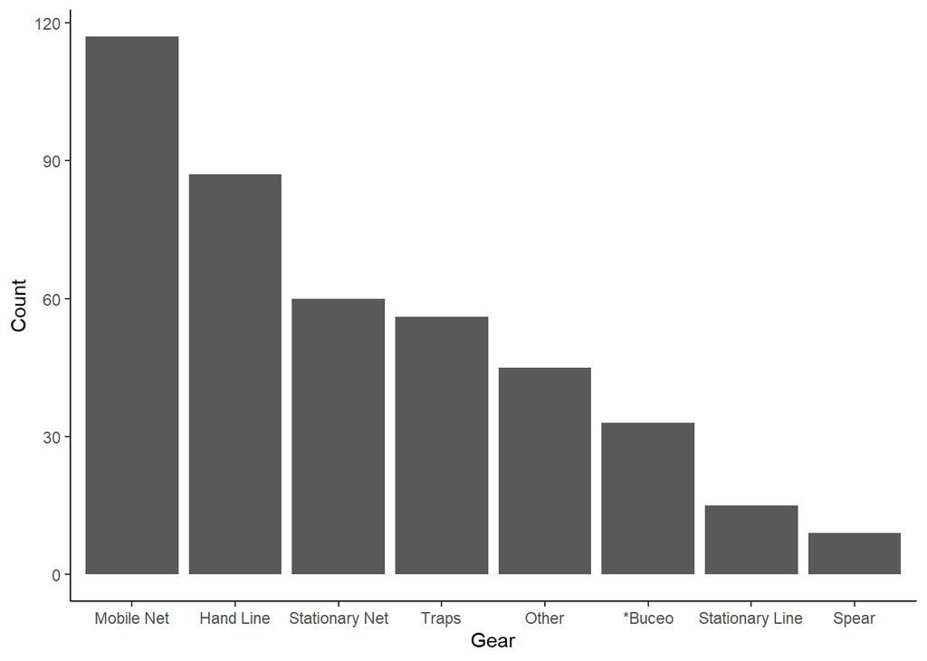

[figure not shown]

Other

```r
#Other Gear Indicated
```

### 5. Vessel Ownership

For fishing purposes, do you own a boat, share a boat, or rent a boat from others, or do not use a boat?

**Total Responses** = 211

[output not shown]

[figure not shown]

### 6. Vessel Characteristics

For your primary fishing vessel, please describe the boat in the following aspects:

#### a. Length

**Total Responses** = 211

| Length (m) | Count |
| --- | --- |
| 2 | 1 |
| 3 | 6 |
| 4 | 3 |
| 5 | 5 |
| 6 | 17 |
| 7 | 62 |
| 8 | 51 |
| 9 | 13 |
| 10 | 11 |
| 11 | 6 |
| 12 | 6 |
| 13 | 1 |
| 15 | 9 |
| 16 | 3 |
| 17 | 12 |
| 20 | 2 |
| 22 | 1 |
| 28 | 1 |
| 100 | 1 |

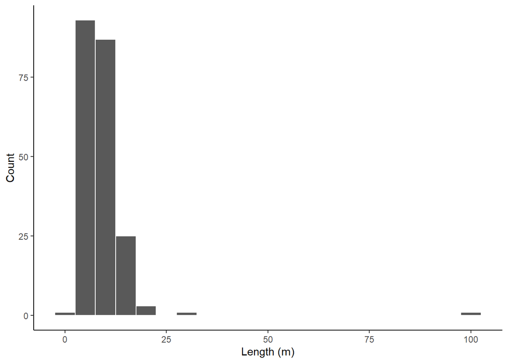

#### b. Material

**Total Responses** = 211

| Material | Count |
| --- | --- |
| Fiberglass | 101 |
| Wood | 110 |

#### c. Is the boat Motorized?

Total Responses = 211

| Motorized | Count |
| --- | --- |
| No | 3 |
| Yes | 208 |

#### d. Is there an onboard power/ electricity source?

Total Responses = 211

| Onboard Power | Count |
| --- | --- |
| No | 56 |
| Yes | 155 |

Comments

### 7. Technology Use

Please check all the types of technology that you use at least once a week, if any

**Total Responses** = 202

| Technology | Count | Percent |
| --- | --- | --- |
| Smart-phone with Internetconnection | 155 | 77 |
| Google Maps or other GPSapps | 74 | 37 |
| Socialmedia (IG, FB, Twitter) | 81 | 40 |
| Other | 14 | 7 |
| None | 33 | 16 |

Other

### 8. Fishing Technology Use

Please check all the types of technology that you use or have used at some point for your fishing activity

**Total Responses** = 206

| Technology | Count | Percent |
| --- | --- | --- |
| VHF Radio | 65 | 32 |
| FishFinder (Sonar) | 49 | 24 |
| Surveillance Camera | 0 | 0 |
| Catch and Data Collection App | 1 | 0 |
| Vessel Tracking Technology | 52 | 25 |
| GPS | 97 | 47 |
| Other | 79 | 38 |
| None | 81 | 39 |

Other

*TEXT*

9. What type of tracking technology did you use on your vessel? *TEXT*
10. Please list some positive aspects of this technology *TEXT*
11. Please list some negative aspects of this technology *TEXT*

## Choice Experiment

12. You have to install and use one or the other tracking package for a year. which would you be more likely to install and use consistently on every fishing trip?
13. Would you prefer the package you chose or no tracking package at all? 14.i. Would you be willing to pay $5 per month for the package you chose? 14.ii. Would you be willing to pay $10 per month for the package you chose? 14.iii. Would you be willing to pay 15 per month for the package you chose? 14.iv. Would you be willing to pay $20 per month for the package you chose? 15.i. Would you be willing to accept a tracking package for $5 per month? 15.ii. Would you be willing to accept a tracking package for $10 per month? 15.iii. Would you be willing to accept a tracking package for $15 per month? 15.iv. Would you be willing to accept a tracking package for $20 per month?
14. Please mention any negatives that this technology might bring to you
15. Please mention any other positives that this technology might bring to you

### 18. Desired Benefits

Please choose 3 benefits you want from the tracking device, if it is installed in your boat

19. In general, why do you think you and your community may or may not not adopt this technology?

*TEXT*

## Catch

20. Combining all seasons, what are your top three targeted fisheries?

### 21. Market Distribution

What percent of the total catch (out of 100%) goes to…

```
## q21_na_count
##  0  1  2  3  4  5
## 87  5 25 20 73  1
```

```
##
##   0  20  45  60  90  95 100 120
##   3   1   1   1   1   1 202   1
```

```
##  fraction_personal fraction_neighbor fraction_local_trade fraction_export
##  Min.   :  0       Min.   : 0        Min.   :  0          Min.   :  0
##  1st Qu.:  0       1st Qu.: 0        1st Qu.:  0          1st Qu.:  0
##  Median :  0       Median : 0        Median : 22          Median :  0
##  Mean   :  5       Mean   : 2        Mean   : 46          Mean   :  5
##  3rd Qu.:  5       3rd Qu.: 0        3rd Qu.:100          3rd Qu.:  0
##  Max.   :100       Max.   :70        Max.   :100          Max.   :100
##  fraction_other
##  Min.   :  0
##  1st Qu.:  0
##  Median :  0
##  Mean   : 41
##  3rd Qu.:100
##  Max.   :100
```

```
##    fraction_personal    fraction_neighbor fraction_local_trade
##                  145                  179                   95
##      fraction_export       fraction_other
##                  189                  117
```

```
##    fraction_personal    fraction_neighbor fraction_local_trade
##                   57                   23                  107
##      fraction_export       fraction_other
##                   13                   85
```

**Total Responses** = 202 *Number of responses that total 100%

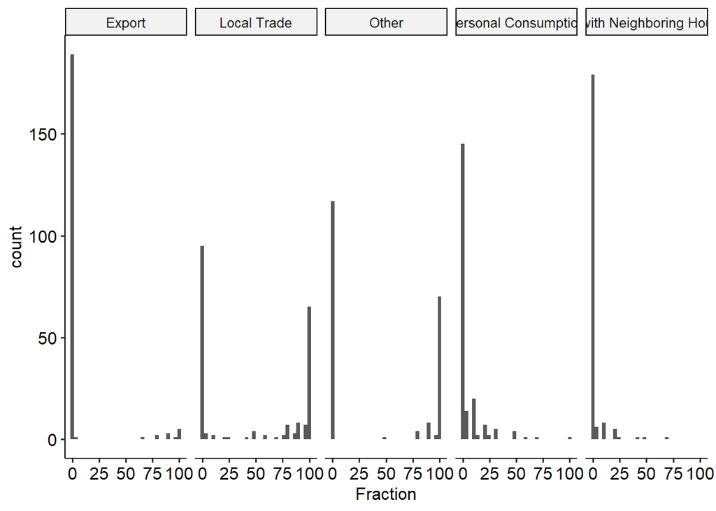

Other

## Fishing Organization

### 22. Membership

Are you part of a fishing organization?

**Total Responses** = 211

| Membership | Count |
| --- | --- |
| No | 75 |
| Yes | 136 |

### 23. Organization Type

What type of organization?

**Total Responses** = 131

| Type of Organization | Count |
| --- | --- |
| Cooperative | 92 |
| Customary Organization | 13 |
| Other | 25 |
| Union | 1 |

Other

### 24. Role in Organization

What role do you have in the organization?

**Total Responses** = 134

| Role in Organization | Count |
| --- | --- |
| Apprentice | 7 |
| Director | 31 |
| Other | 5 |
| Partner | 91 |

Other

### 25. Organization Size

How many members does the organization have?

**Total Responses** = 123

[output not shown]

## Governance

### 26. Access to Fishery

Who is allowed to fish for your #1 targeted fishery?

**Total Responses** = 184

| Access to Target Species | Count |
| --- | --- |
| Anyone with a Permit | 118 |
| Members from you and neighboring fishing organization/ communities | 2 |
| Members of your fishing organization/ community only | 8 |
| Open Access / No Restrictions | 39 |
| Other | 17 |

Other

### 27. Regulations

Please indicate what regulations exist for your #1 targeted fisherie.

**Total Responses** = 181

| Restriction Type | Count |
| --- | --- |
| Gear | 127 |
| Size | 50 |
| Seasonal | 62 |
| Spacial | 76 |
| Quota | 4 |
| Other | 5 |
| No Restrictions | 38 |

Other

### 28. Enforcement

Who is responsible for enforcement in your community?

**Total Responses** = 210

| Enforcement Official | Count |
| --- | --- |
| Community Members | 52 |
| Village Customary Leaders | 21 |
| Village Government | 20 |
| Provincial Government | 68 |
| National Government | 153 |
| No Enforcement | 13 |
| Other | 5 |

Other

### 29. Enforcement Frequency

On average, how often are these fishing regulations enforced?

**Total Responses** = 206

| Enforcement Interval | Count |
| --- | --- |
| Every Week | 67 |
| Few Times per Year | 31 |
| No Enforcement | 42 |
| Once per Month | 14 |
| Once per Week | 28 |
| Once per Year | 9 |
| Other | 15 |

Other

### 30. Severity of Punishment

How severe is the punishment when a person gets caught violating the fishing regulations?

**Total Responses** = 211

| Severity | Count |
| --- | --- |
| Moderate | 50 |
| No Punishment | 31 |
| Severe | 17 |
| Strong | 54 |
| Weak | 59 |

### 31. Closed Areas

Are there any closed areas in your fishing area?

**Total Responses** = 211

| MPA | Count |
| --- | --- |
| No | 122 |
| Yes | 89 |

32. Wat do you think are the biggest problems your fishery faces?

**TEXT**

33. How do you think the problems you mentioned can be solved?

**TEXT**

## Perception

### 34. Rank: Fishing Problems

Please rank the following problems from 1 to 4, where 1 has the strongest impact on your fishing activity and 4 has the least impact on your fishing activity

**Total Responses** = 198

| Problem | Rank 1 | Rank 2 | Rank 3 | Rank 4 |
| --- | --- | --- | --- | --- |
| Extreme Weather Events | 76 | 35 | 26 | 62 |
| Marine Trash and Pollution | 48 | 70 | 55 | 24 |
| Illegal Fishing | 42 | 66 | 80 | 10 |
| Corruption of Fishing Authorities | 32 | 27 | 37 | 102 |

### 35. Catch Trends

In the last few years, the current fish catch has…

**Total Responses** = 210

| Trend | Count |
| --- | --- |
| Declined a Little | 62 |
| Declined a Lot | 37 |
| Improved a Little | 30 |
| Improved a Lot | 6 |
| Stayed the Same | 75 |

## Opinion

### 36. Statements

How much do you agree with the following statements

**Total Responses** = 203

| Statement | Strongly Disagree | Disagree | Neutral | Agree | Strongly Agree |
| --- | --- | --- | --- | --- | --- |
| opinion_a | 3 | 7 | 28 | 114 | 51 |
| opinion_b | 31 | 102 | 19 | 45 | 6 |
| opinion_c | 11 | 33 | 22 | 119 | 18 |
| opinion_d | 7 | 58 | 14 | 74 | 50 |
| opinion_e | 9 | 82 | 20 | 56 | 36 |
| opinion_f | 33 | 99 | 13 | 31 | 27 |
| opinion_g | 6 | 17 | 7 | 76 | 97 |
| opinion_h | 4 | 15 | 16 | 107 | 61 |
| opinion_i | 20 | 24 | 61 | 87 | 11 |

### 37. Groups

Please indicate how much you trust the following groups

**Total Responses** = 166

| Group | Distrust Entirely | Distrust | Neutral | Trust | Trust Entirely |
| --- | --- | --- | --- | --- | --- |
| trust_a | 3 | 12 | 12 | 47 | 92 |
| trust_b | 5 | 21 | 34 | 68 | 38 |
| trust_c | 12 | 20 | 63 | 47 | 24 |
| trust_d | 22 | 24 | 43 | 66 | 11 |
| trust_e | 20 | 27 | 46 | 67 | 6 |
| trust_f | 4 | 10 | 91 | 54 | 7 |
| trust_g | 4 | 7 | 46 | 91 | 18 |
| trust_h | 4 | 6 | 75 | 66 | 15 |
| trust_i | 4 | 11 | 52 | 82 | 17 |
| trust_j | 4 | 20 | 23 | 105 | 14 |
| trust_k | 4 | 19 | 23 | 106 | 14 |
| trust_l | 7 | 22 | 93 | 37 | 7 |

### 38. Organizations

Please indicate how satisfied you were when working with the following organizations

**Total Responses** = 193

| Organization | N/A | Extremely Unsatisfied | Unsatisfied | Neutral | Satisfied | Extremely Satisfied |
| --- | --- | --- | --- | --- | --- | --- |
| satisfaction_a | 54 | 0 | 2 | 94 | 31 | 12 |
| satisfaction_b | 43 | 6 | 12 | 87 | 43 | 2 |
| satisfaction_c | 25 | 7 | 19 | 70 | 68 | 4 |

## Demographics

### 39. Age

What is your age?

**Total Responses** = 211

| Age Group | Count |
| --- | --- |
| [15,20) | 8 |
| [20,25) | 7 |
| [25,30) | 14 |
| [30,35) | 20 |
| [35,40) | 37 |
| [40,45) | 41 |
| [45,50) | 28 |
| [50,55) | 20 |
| [55,60) | 22 |
| [60,65) | 9 |
| [65,70) | 4 |
| [70,75) | 0 |
| [75,80) | 1 |

### 40. Fishing Experience

How many years have you been fishing?

**Total Responses** = 211

| Years Group | Count |
| --- | --- |
| [0,5) | 10 |
| [5,10) | 19 |
| [10,15) | 18 |
| [15,20) | 26 |
| [20,25) | 38 |
| [25,30) | 26 |
| [30,35) | 33 |
| [35,40) | 16 |
| [40,45) | 13 |
| [45,50) | 5 |
| [50,55) | 4 |
| [55,60) | 2 |

### 41. Education

What is your level of education? (Please choose one)

**Total Responses** = 211

| Education Level | Count |
| --- | --- |
| College / University | 8 |
| No Formal Education | 9 |
| Other | 23 |
| Primary School | 101 |
| Secondary / High School | 63 |
| Vocational Training / Trade School | 7 |

Other

```r
edu_other<-survey %>%
  select(survey_id,country, contains("edu")) %>%
  filter(education=="other")
```

### 42. Income

What is your average monthly income?

**Total Responses** = 203

| mean | n |
| --- | --- |
| 1918785 | 203 |

### 43. Percent Income - Fishing

What percent (out of 100%) of your annual income comes from fishing?

**Total Responses** = 205

| Percent Income from Fishing | Count |
| --- | --- |
| [0,10) | 1 |
| [10,20) | 19 |
| [20,30) | 2 |
| [30,40) | 2 |
| [40,50) | 3 |
| [50,60) | 16 |
| [60,70) | 2 |
| [70,80) | 7 |
| [80,90) | 4 |
| [90,100) | 3 |

### 44. Percent Income - Expenses

What percent (out of 100%) of your income is spent on expenses related to fishing?

**Total Responses** = 203

| Percent Income on Expenses | Count |
| --- | --- |
| [0,10) | 14 |
| [10,20) | 41 |
| [20,30) | 47 |
| [30,40) | 39 |
| [40,50) | 22 |
| [50,60) | 29 |
| [60,70) | 7 |
| [70,80) | 0 |
| [80,90) | 4 |
| [90,100) | 0 |

Photo of the Fishing Vessel if available (or other relevant material) Any additional questions, comments, notes, etc….

# Basic CE Related Numbers

```r
library(mlogit)
data("Electricity", package = "mlogit")

Electr <- mlogit.data(Electricity, id="id", choice="choice", varying=3:26, shape="wide", sep="")
```